# Neural & Behavioral Modeling - Week 3 (Exercises)

by 李彥廷 (b08207008@ntu.edu.tw)

```python
%config IPCompleter.greedy=True
%matplotlib inline
from numpy import *
import matplotlib.pyplot as plt
from matplotlib import ticker
import pandas as pd
from IPython.display import *
import scipy.stats as stats
from itertools import *
from sklearn.preprocessing import scale
```

## 1 Replicate exisiting findings/models (10 points)

Based on your personal interest, please choose and replicate ONE of the following studies:

1. [Flocking Vee Formations](http://ccl.northwestern.edu/netlogo/models/FlockingVeeFormations) in NetLogo's [Sample Models::Biology]
2. [Wolf-Sheep Predation](http://ccl.northwestern.edu/netlogo/models/WolfSheepPredation) in NetLogo's [Sample Models::Biology]
3. [MIT Matching Game](https://kknews.cc/zh-tw/news/p56pbrp.html)
4. Gray, K., Rand, D. G., Ert, E., Lewis, K., Hershman, S., & Norton, M. I. (2014). [The emergence of “us and them” in 80 lines of code: Modeling group genesis in homogeneous populations](http://www.mpmlab.org/groups/). Psychological Science, 25(4), 982-990.
5. Luhmann, C. C., & Rajaram, S. (2015). [Memory transmission in small groups and large networks: An agent-based model](http://journals.sagepub.com/doi/abs/10.1177/0956797615605798). Psychological Science, 26(12), 1909-1917.
6. Henriques, G. J., Simon, B., Ispolatov, Y., & Doebeli, M. (2019). [Acculturation drives the evolution of intergroup conflict](https://www.pnas.org/content/116/28/14089). Proceedings of the National Academy of Sciences, 116(28), 14089-14097.

## 2 Luhmann, C. C., & Rajaram, S. (2015). Memory transmission in small groups and large networks: An agent-based model

I built an agent based model in this paper and replicate their study 1 and study 2.

### 2.1 Classes and Functions

I've create a class of **Person**, which can be used to instantiate participants in memory tasks. These agents are characterized with given parameters and are able to encode or retrieve experiment stimuli.

In the memory task, participants in a collaborative group are required to recall stimuli together, and the total number of recalled stimuli is taken as the performance. While in nominal group, particiants recall stimuli in isolation and the performance is the number of nonredundant stimuli recalled by member in the group, that is, the union of the stimuli recalled by the member.

```python
# Write your codes here
class Person:
    '''
    A person endowed with the ability to encode and retrieve stimuli.
    '''
    def __init__(self, alpha, beta, gamma, itemList, encode_order, S):
        '''
        Specifies three parameters and itemList to study.
        A and S are activation vector and inter-item associations w.r.t to itemList.
        A must be a list or array with same length as that of itemList.
        S must be a 2d-array or matrix with the number of rows and columns is same as the length of itemList.
        if A and S are not given, they will be randomly generated.
        '''
        self.alpha=alpha
        self.beta=beta
        self.gamma=gamma
        self.itemList=array(itemList)
        NitemList = len(self.itemList)
        self.A = zeros(NitemList)
        self.S = array(S)
        fill_diagonal(self.S, 1) # Self association = 1
        for o in encode_order:
            self.encode(o)
        self.iniA=self.A.copy()

    def encode(self, item):
        '''
        Encode the "item" and update Activation vector according to
        inter-item associations
        '''
        [item_index], = where(self.itemList == item)
        A_item = self.A[item_index]
        # Update Activation vector
        if A_item != self.A.max(): # not the maximum activated item
            A_max = self.A.max()
            [A_max_index], = where(self.A == A_max)
            S_max_j = self.S[A_max_index]
            self.A = self.A - self.beta*S_max_j*self.A # combine eq1 and eq2 by filling S_diag with 1
        self.A[item_index] = A_item + self.alpha*(1-A_item) # eq3
        self.A = self.A/self.A.sum(axis=0) # normalize activation vector

    def retrieve(self, retrivedItemList):
        '''
        #1 Determine whether the retrieving process is successful.
        #2 If true, retrive an item from itemList according to probability from activation vector.
        #3 The retrieving process will fail if the retrieved item was previously retrieved.
        '''
        success_retrieve = bool(random.binomial(1,self.gamma)) #1 success_retrieve or not
        #2 if success, pick one item from itemList according to prob. from activation vector
        if success_retrieve:
            self.A = self.A/self.A.sum(axis=0) # normalize again to prevent float-point error
            retrieved_item = random.choice(self.itemList, p=self.A)
            [retrieve_item_idx], = where(self.itemList == retrieved_item)
            #3 Fail to recall if the item was previously retrieved
            if retrieved_item not in retrivedItemList:
                S_item_j = self.S[retrieve_item_idx].copy() # temporary copy
                S_item_j[retrieve_item_idx] = 0 # prevent modification of A_i from setting S_ii to 0
                self.A = self.A + self.beta*S_item_j*self.A # eq4
                return retrieved_item
```

```python
class CMT:
    '''
    Collaborative Memory Task
    '''
    def __init__(self, NRound, NItem):
        '''Specified the number of Round and studying stimuli in a Collaborative Memory Task.'''
        self.NRound = NRound
        self.itemList = arange(NItem)
        self.retrievedItemList = []
        self.result=None

    def AddParticipants(self, alpha, beta, gamma, N, encode_ord_lst, Slist):
        '''Add a number of participants with given parameters.'''
        for i in range(N):
            # study solely
            self.SubjectList.append(Person(alpha, beta, gamma, self.itemList, encode_ord_lst[i], S=Slist[i]))

    def get_Similarity(self):
        '''
        Get the current similarity between Activation vector of participants in a group.
        '''
        CList = list(combinations(self.SubjectList,2)) # C(3,2) of participants
        ALst = [(sub[0].A, sub[1].A) for sub in CList]
        iniALst = [(sub[0].iniA, sub[1].iniA) for sub in CList]
        ApearsonrList = [stats.pearsonr(*pair)[0] for pair in ALst]
        iniApearsonrList = [stats.pearsonr(*pair)[0] for pair in iniALst]
        preSim, postSim = mean(iniApearsonrList), mean(ApearsonrList)
        return preSim, postSim

    def get_Results(self, getSim=False):
        '''
        Run the corresponding experiment of the group and return the result.
        '''
        self.Run()
        return self.retrievedItemList, self.result

class ColabGroup(CMT):
    def __init__(self, NRound, NItem):
        super().__init__(NRound, NItem)
        self.SubjectList = []

    def Run(self):
        '''
        #1 During each round, each agent was given an opportunity to retrieve an item.
        #2 The order in which the agents executed the retrieval was determined randomly in each round.
        #3 If an agent successfully retrieved an item, it was encoded by the other two agents.
        #4 If an agent attempted to retrieve a previously retrieved item, this retrieval failed.
        '''
        for i in range(self.NRound):
            random.shuffle(self.SubjectList) #2
            for sub in self.SubjectList: #1
                r_item = sub.retrieve(self.retrievedItemList) #4
                if r_item is not None:
                    self.retrievedItemList.append(r_item)
                    for sub in self.SubjectList: #3
                    # encode the retrieved item
                        sub.encode(r_item)
        self.result = len(self.retrievedItemList)

class NominalGroup(CMT):
    def __init__(self, NRound, NItem):
        super().__init__(NRound, NItem)
        self.SubjectList = []

    def Run(self):
        '''
        In a nominal group, each participants recall words individually.
        The performance is calculated as nonredundant recall of all participants in the group.
        '''
        Separate_rlist = [[] for i in self.SubjectList]
        for i in range(len(self.SubjectList)):
            for r in range(self.NRound):
                sub = self.SubjectList[i]
                rlist = Separate_rlist[i]
                r_item = sub.retrieve(rlist)
                if r_item is not None:
                    rlist.append(r_item)
                    sub.encode(r_item)
        self.retrievedItemList = list(set.union(*map(set, Separate_rlist)))
        self.result = len(self.retrievedItemList)
```

```python
def Simulation(NSim, NRound=20, NItem=40, Npeople=3, alpha=.2, beta=.05, gamma=.75):

    P_Col_list = []; P_Nom_list = []
    Pre_Sim_list = []
    PostCol_Sim_list = []; PostNom_Sim_list = []

    for s in range(NSim):
        # random encode order and interitem association share by two groups
        random_ord_lst=[random.choice(arange(NItem),size=NItem, replace=False) for i in range(Npeople)]
        randomSlist=[]
        for i in range(Npeople):
            temp = random.uniform(-.2,.2,size=(NItem,NItem))
            S = (temp + temp.T)/2
            fill_diagonal(S,1)
            randomSlist.append(S)

        # ======= Nominal Group =======
        NGroup = NominalGroup(NRound=NRound, NItem=NItem)
        NGroup.AddParticipants(alpha, beta, gamma, N=Npeople, encode_ord_lst=random_ord_lst, Slist=randomSlist)
        RList_NG, P_NG = NGroup.get_Results()
        preSimN, postSimN = NGroup.get_Similarity()
        P_Nom_list.append(P_NG)
        Pre_Sim_list.append(preSimN)
        PostNom_Sim_list.append(postSimN)

        # ======= Colaborative Group =======
        CGroup = ColabGroup(NRound=NRound, NItem=NItem)
        CGroup.AddParticipants(alpha, beta, gamma, N=Npeople, encode_ord_lst=random_ord_lst, Slist=randomSlist)
        RList_CG, P_CG = CGroup.get_Results()
        preSimC, postSimC = CGroup.get_Similarity()
        P_Col_list.append(P_CG)
        PostCol_Sim_list.append(postSimC)

    return P_Col_list, P_Nom_list, Pre_Sim_list, PostCol_Sim_list, PostNom_Sim_list

def pairedTtest(X1, X2):
    x1 = array(X1[0])
    x2 = array(X2[0])
    x1_bar = x1.mean()
    x2_bar = x2.mean()
    Tstat, pvalue = stats.ttest_rel(x2, x1, alternative='greater')
    if pvalue<0.0001:
        pvalue=0.0001
    df = len(x1)-1
    stdev = std(x2 - x1)
    CohenD = (x2_bar-x1_bar)/stdev
    print("========Paired Sample t test========")
    print(X1[1], round(x1_bar,4),sep='\n')
    print(X2[1], round(x2_bar,4),sep='\n')
    print()
    print(f't({df})={round(Tstat,4)}', ',' , f"p<{round(pvalue,4)}")
    print('Cohen\'s d =', round(CohenD,4))
    print("====================================")

def jitter(ax):
    dots = ax.collections[-1]
    offsets = dots.get_offsets()
    jittered_offsets = offsets + random.uniform(0, 0.025, offsets.shape)
    dots.set_offsets(jittered_offsets)

def regline(ax, x, y):
    m, b = polyfit(x, y, 1)
    ax.plot(x, m*x+b, color='black')
    r, p = stats.pearsonr(x,y)
    return r, p

def plotRelation(PreColab_Sim_list, P_Nom_list, P_Col_list, NItem):
    x = scale(PreColab_Sim_list)
    y_n = array(P_Nom_list)/NItem
    y_c = array(P_Col_list)/NItem
    y = [y_n,y_c]
    yname = ['Nominal Group','Collaborative Group']
    fig, axes = plt.subplots(1,2, figsize = (10,5), dpi=500)
    fig.tight_layout(pad=3.0)
    for i in range(2):
        axes[i].scatter(x, y[i], marker='o',linewidth=0.15,alpha=.6,color='#B44F3D',edgecolors='black')
        axes[i].set_xlim([-4, 4])
        axes[i].set_ylim([y[i].min()-0.1, y[i].max()+0.1])
        axes[i].spines["top"].set_visible(False)
        axes[i].spines["right"].set_visible(False)
        axes[i].set_xlabel('Precollaboration Similarity')
        axes[i].set_ylabel(yname[i]+' Recall')
        r, p = regline(axes[i], x, y[i])
        if p < 0.0001:
            p = 0.0001
        print(f'{yname[i]}: r={round(r,4)}, p<{round(p,4)}')
        jitter(axes[i])
```

### 2.2 Study 1: Comparing Performance of Two Groups

Simulated 1,000 separate pairs of groups (i.e., 1,000 collaborative groups and 1,000 nominal groups) and compare the percentage of words recalled in the studying list between collaborative groups and nominal groups. The parameter of all agents were alpha = .2, beta = .05, gamma = .75. The agents in collaborative groups is identical to the agents in nominal groups. They contain the same sets of activation vectors so that the differences between two groups only result from the task design.

```python
Results = Simulation(1000)
P_Col_list, P_Nom_list, Pre_Sim_list, PostCol_Sim_list, PostNom_Sim_list = Results
```

### 2.3 Results

In my simulation, Nominal Group performed significantly better than Collaborative Group, which showed the **Collaboration Inhibition**, but the mean performance and the effect size are not as large as the original paper, where the mean performance are about 0.65 and 0.4 for nominal group and collaborative group respectively.

```python
pairedTtest((P_Col_list,'Mean # of items recalled in Collaborative Group:'),
            (P_Nom_list,'Mean # of items recalled in Nominal Group:'))
```

```
========Paired Sample t test========
Mean # of items recalled in Collaborative Group:
10.916
Mean # of items recalled in Nominal Group:
15.929

t(999)=67.2272 , p<0.0001
Cohen's d = 2.127
====================================
```

### 2.4 How Similarity within Groups Affect Performance

In the original paper, they found that when the similarity of Activation vector within group before tasks affect the performance in nonminal group. Because members in nominal group recall items independently, so high similarity of activation vector increase overlap of recalled items, which in turn dampen the performance. For collaboration groups, higher similarity doesn't affect performance much, because similarity will eventually increase through collaboration.

In the following figure, as percollaboration similarity increase the recall rate slight decrease and this effect is larger for nominal groups. In my simulation, the pearson's correlation is smaller than that in the original study, where the correlation coefficient was -.39.

```
Nominal Group: r=-0.2468, p<0.0001
Collaborative Group: r=-0.0685, p<0.0303
```

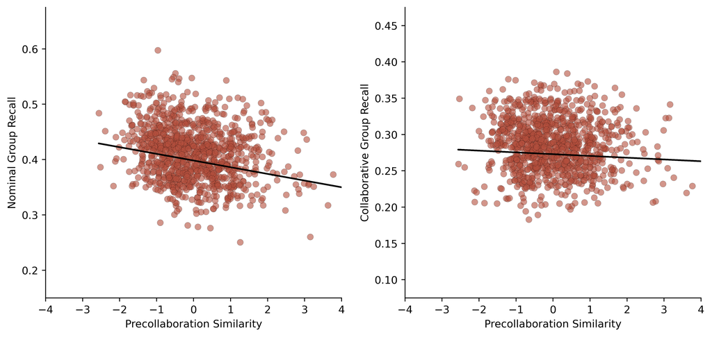

```python
print()
plotRelation(Pre_Sim_list, P_Nom_list, P_Col_list, NItem=40)
```

### 2.5 Pre- and Post-Task Similarity

For Collaborative Group, the similarity increased.  
For Nominal Group, the similarity remained the same.

```python
pairedTtest((Pre_Sim_list,'Pre-Task Similarity of Collaborative Group:'),
            (PostCol_Sim_list,'Post-Task Similarity of Collaborative Group:'))
```

```
========Paired Sample t test========
Pre-Task Similarity of Collaborative Group:
0.0014
Post-Task Similarity of Collaborative Group:
0.9833

t(999)=348.0401 , p<0.0001
Cohen's d = 11.0115
====================================
```

```python
pairedTtest((Pre_Sim_list,'Pre-Task Similarity of Collaborative Group:'),
            (PostNom_Sim_list,'Post-Task Similarity of Collaborative Group:'))
```

```
========Paired Sample t test========
Pre-Task Similarity of Collaborative Group:
0.0014
Post-Task Similarity of Collaborative Group:
0.0034

t(999)=0.6865 , p<0.2463
Cohen's d = 0.0217
====================================
```

## 3 Study 2: Manipulate Group size

Change the group size to see how group size affect collaboration inhibition. The group size in the simulaiton ranges from 2 to 128.

```python
GroupSize = [2, 3, 4, 5, 6, 8, 10, 16, 32, 64, 128]
dataList=[]
for Gsize in GroupSize:
    Col_list=[]; Nom_list=[]
    for s in range(1000):
        NItem=40; NRound=20; Npeople=Gsize;
        alpha, beta, gamma = .2, .05, .75
        # random encode order and interitem association share by two groups
        random_ord_lst=[random.choice(arange(NItem),size=NItem, replace=False) for i in range(Npeople)]
        randomSlist=[]
        for i in range(Npeople):
            temp = random.uniform(-.2,.2,size=(NItem,NItem))
            S = (temp + temp.T)/2
            fill_diagonal(S,1)
            randomSlist.append(S)

        # ======= Nominal Group =======
        NGroup = NominalGroup(NRound=NRound, NItem=NItem)
        NGroup.AddParticipants(alpha, beta, gamma, N=Npeople, encode_ord_lst=random_ord_lst, Slist=randomSlist)
        RList_NG, P_NG = NGroup.get_Results()
        Nom_list.append(P_NG/NItem)

        # ======= Colaborative Group =======
        CGroup = ColabGroup(NRound=NRound, NItem=NItem)
        CGroup.AddParticipants(alpha, beta, gamma, N=Npeople, encode_ord_lst=random_ord_lst, Slist=randomSlist)
        RList_CG, P_CG = CGroup.get_Results()
        Col_list.append(P_CG/NItem)

    dataList.append({'GroupSize':Gsize,
                     'ColGroup':mean(Col_list),
                     'NomGroup':mean(Nom_list),
                     'Inhibition':mean(Nom_list)-mean(Col_list)})
df = pd.DataFrame.from_records(dataList)
```

### 3.1 Results

The figure show the performace of two kinds of group and how collaboration inhibition changes as group size increases. My figure show similar trend as the original paper, but the value were not the same because the performance were consistently smaller in my simulation.

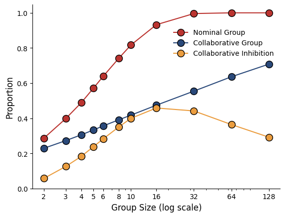

```python
fig, ax1 = plt.subplots(figsize = (6.4,4.8))
dct=dict(marker='o',ms=10,mew=1,mec='black')
ax1.plot(df.GroupSize, df.NomGroup, color='#BB3430', **dct)
ax1.plot(df.GroupSize, df.ColGroup, color='#2A497A', **dct)
ax1.plot(df.GroupSize, df.Inhibition, color='#EB9D3F', **dct)
ax1.legend(['Nominal Group','Collaborative Group','Collaborative Inhibition']
           , loc=1, bbox_to_anchor=(1, 0.9), frameon=False)
ax1.spines["top"].set_visible(False)
ax1.spines["right"].set_visible(False)
ax1.set_xscale('log')
ax1.set_xticks(GroupSize); ax1.set_yticks(linspace(0,1,6))
ax1.set_xlabel('Group Size (log scale)',size=12)
ax1.set_ylabel('Proportion', size=12)
ax1.get_xaxis().set_major_formatter(ticker.ScalarFormatter())
```